## Machine Learning Assignment

### Assignment Objective

The purpose of this assignment is to develop a model that will predict how well a person can  
perform a bar bell lift using data from multiple accelerometers. The data used to produce  
the model comes from the Weight Lifting Exercise dataset from the Human Activity Recognition  
project. The data was collected from a set of accelerometers connected to the arm, forearm,  
belt, and dumbbell while five participants performed one set of 10 unilateral dumbbell  
biceps curls.

### Analysis Steps

The first section of code loads the caret package that will be used for model development and  
loads two datasets from the website: a set complete with exercise classifications and a set  
that has not been classified and that will be used for model verification.

```r
library(caret)
```

```r
alldata=read.csv(url("https://d396qusza40orc.cloudfront.net/predmachlearn/pml-training.csv"))
quiz=read.csv(url("https://d396qusza40orc.cloudfront.net/predmachlearn/pml-testing.csv"))
```

Performing a few data summaries reveals that many of the variables in the dataset have a  
large number of readings that are either blank or NA. In addition, there are a few variables  
that serve as row markers or timestamps. Prior to model development, we will eliminate these  
variables from the dataset. This will reduce the total number of variables from 160 to 55 and  
will speed up the model development steps.

```r
mydata <- alldata[,colSums(is.na(alldata))<19000]
mydata <- mydata[,colSums(mydata=="")<19000]
mydata=mydata[,6:60]
```

Now that the data has been cleaned, we will divide the data into a training set to build the  
model and a testing set to cross-validate the model. We will use random subsetting without  
replacement. For reproducibility purposes, we will set a seed in R prior to making the split.

```r
set.seed(123)
inTrain=createDataPartition(y=mydata$classe,p=0.75,list=FALSE)
training=mydata[inTrain,]
testing=mydata[-inTrain,]
```

In the next step, we will use the training set to build a model. for this exercise, we will  
use a random forest model. The random forest technique builds multiple decision trees with  
the data and uses the multiple trees to vote for the correct class. The model can take  
longer to generate but is very accurate. For this model, the output variable is classe. We  
will use all remaining variables in the dataset as predictors. Again, for reproducibility  
purposes, we will set a seed in R so that the exact random forest can be recreated.

```r
set.seed(516)
modFitrf=train(classe~.,data=training,method="rf")
```

Now that the model has been built, we will validate the accuracy of the model by using it  
to predict classe values in the testing set that we created with the earlier split. Since  
the testing set already contains values for classe, we can compare our predicted values to  
the actual values from the dataset to see how accurate the model is. We will generate a  
confusion matrix that will show how often the model agrees with the actual values (accuracy).  
We will also be able to see various statistics for each of the five potential outcomes,  
including sensitivity, specificity.

```r
pred=predict(modFitrf,testing)
confusionMatrix(pred,testing$classe)
```

```
## Confusion Matrix and Statistics
##
##           Reference
## Prediction    A    B    C    D    E
##          A 1395    1    0    0    0
##          B    0  948    1    0    0
##          C    0    0  854    3    0
##          D    0    0    0  801    0
##          E    0    0    0    0  901
##
## Overall Statistics
##
##                Accuracy : 0.999
##                  95% CI : (0.9976, 0.9997)
##     No Information Rate : 0.2845
##     P-Value [Acc > NIR] : < 2.2e-16
##
##                   Kappa : 0.9987
##  Mcnemar's Test P-Value : NA
##
## Statistics by Class:
##
##                      Class: A Class: B Class: C Class: D Class: E
## Sensitivity            1.0000   0.9989   0.9988   0.9963   1.0000
## Specificity            0.9997   0.9997   0.9993   1.0000   1.0000
## Pos Pred Value         0.9993   0.9989   0.9965   1.0000   1.0000
## Neg Pred Value         1.0000   0.9997   0.9998   0.9993   1.0000
## Prevalence             0.2845   0.1935   0.1743   0.1639   0.1837
## Detection Rate         0.2845   0.1933   0.1741   0.1633   0.1837
## Detection Prevalence   0.2847   0.1935   0.1748   0.1633   0.1837
## Balanced Accuracy      0.9999   0.9993   0.9990   0.9981   1.0000
```

Since the testing set was not utilized to build the model, the model’s performance on the  
test set will give a good idea of what its out of sample error would be. Based on the  
confusion matrix, the model had an accuracy of 99.9% on the testing set and  
miscategorized only 5 samples out of 4904. The No information rate shows how accurate we  
would expect to be in making predictions with no model at all. The random forest model  
improves that accuracy by 71%, which is statistically significant based on the p-value. The  
confidence interval on the accuracy is also very small due to the large number of samples in  
the testing set. The individual sensitivities and specificities for each category are also extremely high. Overall, the model performed extremely well.

Next, we can look at which variables in the model were the most important for the model. The  
most important variable was num window followed by Toll belt. The rest of the variables,  
ranked by importance, can be seen in the plot below:

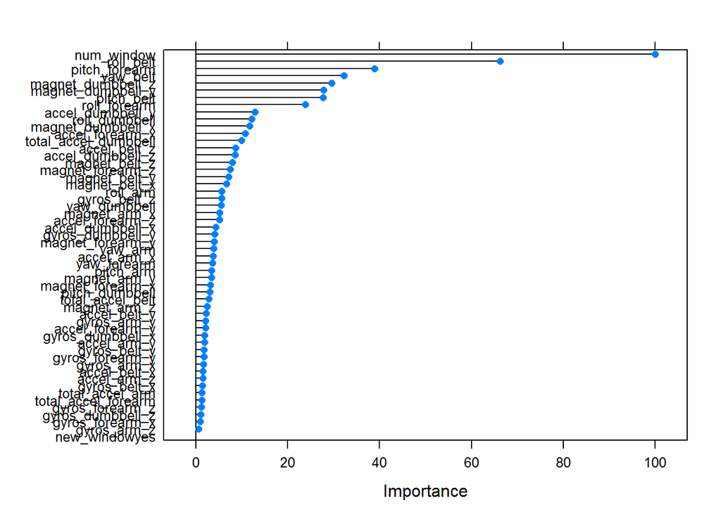

Now that we have verified the performance of the model through cross-validation and gained  
some insight into which variables had the biggest impact on the model, the final step is to  
use the model to predict categories for the 20 samples for the quiz. Unlike the validation  
on the testing set, we do not already know the categories for the quiz samples. The  
predictions for these samples are as follows:

```r
predquiz=predict(modFitrf,quiz)
predquiz
```

```
##  [1] B A B A A E D B A A B C B A E E A B B B
## Levels: A B C D E
```

These answers were submitted through the Coursera assessment and were all correct.

### Conclusion

The model was validated twice: once on the testing set and once on the quiz set and was  
extremely accurate in both. Based on these results, it is fair to say that the sensors  
in the accelerometers can be used to accurately say whether a dumbbell lift is being performed  
correctly. A customer can have confidence that he is performing the exercise correctly  
as long as his sensors do not indicate otherwise.